# Study of the Diamonds tidyverse dataset with a focus on diamond quality

### **Driving Question**: Why are low-quality diamonds more expensive?

```r
library(viridis)
library(tidyverse)
library(ggplot2)
library(gridExtra)
library(corrr)
```

## -1- Loading the dataset & summary

The Diamonds dataset contains the prices and other attributes of **53940 diamonds**.

```r
data <- diamonds
summary(data)
```

```
##      carat               cut        color        clarity          depth
##  Min.   :0.2000   Fair     : 1610   D: 6775   SI1    :13065   Min.   :43.00
##  1st Qu.:0.4000   Good     : 4906   E: 9797   VS2    :12258   1st Qu.:61.00
##  Median :0.7000   Very Good:12082   F: 9542   SI2    : 9194   Median :61.80
##  Mean   :0.7979   Premium  :13791   G:11292   VS1    : 8171   Mean   :61.75
##  3rd Qu.:1.0400   Ideal    :21551   H: 8304   VVS2   : 5066   3rd Qu.:62.50
##  Max.   :5.0100                     I: 5422   VVS1   : 3655   Max.   :79.00
##                                     J: 2808   (Other): 2531
##      table           price             x                y
##  Min.   :43.00   Min.   :  326   Min.   : 0.000   Min.   : 0.000
##  1st Qu.:56.00   1st Qu.:  950   1st Qu.: 4.710   1st Qu.: 4.720
##  Median :57.00   Median : 2401   Median : 5.700   Median : 5.710
##  Mean   :57.46   Mean   : 3933   Mean   : 5.731   Mean   : 5.735
##  3rd Qu.:59.00   3rd Qu.: 5324   3rd Qu.: 6.540   3rd Qu.: 6.540
##  Max.   :95.00   Max.   :18823   Max.   :10.740   Max.   :58.900
##
##        z
##  Min.   : 0.000
##  1st Qu.: 2.910
##  Median : 3.530
##  Mean   : 3.539
##  3rd Qu.: 4.040
##  Max.   :31.800
##
```

## -2- Available features

There are 10 available variables in the dataset (including price):

- **price**: price in US dollars ($326–$18,823)
- **carat**: weight of the diamond (0.2–5.01)
- **cut**: quality of the cut (Fair, Good, Very Good, Premium, Ideal)
- **color**: diamond colour, from D (best) to J (worst)
- **clarity**: a measurement of how clear the diamond is (I1 (worst), SI2, SI1, VS2, VS1, VVS2, VVS1, IF (best))
- **x**: length in mm (0–10.74)
- **y**: width in mm (0–58.9)
- **z**: depth in mm (0–31.8)
- **depth**: total depth percentage = z / mean(x, y) = 2 * z / (x + y) (43–79)
- **table**: width of top of diamond relative to widest point (43–95)

[output not shown]

## -3- ‘Fair’ diamonds

We find **1610 ‘Fair’ cut diamonds in the dataset**, i.e., about 3% of the dataset.

```r
fair_data <- data %>%
  filter(cut=="Fair")
fair_data %>% head(5)
```

```
## # A tibble: 5 x 10
##   carat cut   color clarity depth table price     x     y     z
##   <dbl> <ord> <ord> <ord>   <dbl> <dbl> <int> <dbl> <dbl> <dbl>
## 1  0.22 Fair  E     VS2      65.1    61   337  3.87  3.78  2.49
## 2  0.86 Fair  E     SI2      55.1    69  2757  6.45  6.33  3.52
## 3  0.96 Fair  F     SI2      66.3    62  2759  6.27  5.95  4.07
## 4  0.7  Fair  F     VS2      64.5    57  2762  5.57  5.53  3.58
## 5  0.7  Fair  F     VS2      65.3    55  2762  5.63  5.58  3.66
```

```r
summary(fair_data)
```

```
##      carat              cut       color      clarity        depth
##  Min.   :0.220   Fair     :1610   D:163   SI2    :466   Min.   :43.00
##  1st Qu.:0.700   Good     :   0   E:224   SI1    :408   1st Qu.:64.40
##  Median :1.000   Very Good:   0   F:312   VS2    :261   Median :65.00
##  Mean   :1.046   Premium  :   0   G:314   I1     :210   Mean   :64.04
##  3rd Qu.:1.200   Ideal    :   0   H:303   VS1    :170   3rd Qu.:65.90
##  Max.   :5.010                    I:175   VVS2   : 69   Max.   :79.00
##                                   J:119   (Other): 26
##      table           price             x                y
##  Min.   :49.00   Min.   :  337   Min.   : 0.000   Min.   : 0.000
##  1st Qu.:56.00   1st Qu.: 2050   1st Qu.: 5.630   1st Qu.: 5.570
##  Median :58.00   Median : 3282   Median : 6.175   Median : 6.100
##  Mean   :59.05   Mean   : 4359   Mean   : 6.247   Mean   : 6.183
##  3rd Qu.:61.00   3rd Qu.: 5206   3rd Qu.: 6.700   3rd Qu.: 6.640
##  Max.   :95.00   Max.   :18574   Max.   :10.740   Max.   :10.540
##
##        z
##  Min.   :0.000
##  1st Qu.:3.610
##  Median :3.970
##  Mean   :3.983
##  3rd Qu.:4.280
##  Max.   :6.980
##
```

## -4- ‘Fair’ and ‘Good’ diamonds under $600

```r
fg_under600_data <- data %>%
  filter(cut=="Fair" | cut=="Good") %>%
  filter(price<=600)
fg_under600_data %>% head(5)
```

```
## # A tibble: 5 x 10
##   carat cut   color clarity depth table price     x     y     z
##   <dbl> <ord> <ord> <ord>   <dbl> <dbl> <int> <dbl> <dbl> <dbl>
## 1  0.23 Good  E     VS1      56.9    65   327  4.05  4.07  2.31
## 2  0.31 Good  J     SI2      63.3    58   335  4.34  4.35  2.75
## 3  0.22 Fair  E     VS2      65.1    61   337  3.87  3.78  2.49
## 4  0.3  Good  J     SI1      64      55   339  4.25  4.28  2.73
## 5  0.3  Good  J     SI1      63.4    54   351  4.23  4.29  2.7
```

```r
summary(fg_under600_data)
```

```
##      carat               cut      color      clarity        depth
##  Min.   :0.2200   Fair     : 17   D: 75   SI1    :195   Min.   :55.20
##  1st Qu.:0.3000   Good     :488   E:104   VS2    : 80   1st Qu.:63.10
##  Median :0.3100   Very Good:  0   F: 81   SI2    : 77   Median :63.40
##  Mean   :0.3075   Premium  :  0   G: 61   VS1    : 77   Mean   :63.02
##  3rd Qu.:0.3200   Ideal    :  0   H: 93   VVS2   : 35   3rd Qu.:63.70
##  Max.   :0.5000                   I: 63   VVS1   : 31   Max.   :69.80
##                                   J: 28   (Other): 10
##      table           price             x               y
##  Min.   :52.00   Min.   :327.0   Min.   :3.830   Min.   :3.780
##  1st Qu.:55.00   1st Qu.:449.0   1st Qu.:4.230   1st Qu.:4.260
##  Median :56.00   Median :506.0   Median :4.290   Median :4.310
##  Mean   :56.97   Mean   :499.5   Mean   :4.287   Mean   :4.311
##  3rd Qu.:58.00   3rd Qu.:554.0   3rd Qu.:4.360   3rd Qu.:4.390
##  Max.   :66.00   Max.   :600.0   Max.   :4.890   Max.   :4.800
##
##        z
##  Min.   :2.310
##  1st Qu.:2.690
##  Median :2.730
##  Mean   :2.709
##  3rd Qu.:2.770
##  Max.   :3.380
##
```

## -5- Mean price over the whole dataset

We find that the mean price of a diamond (regardless of its features) in the Diamonds dataset is about **3932.8 in US dollars**.

```r
round(mean(data$price), digits=2)
```

```
## [1] 3932.8
```

## -6 & 7- Building the ‘color’ & ‘clarity’ groupings

We find that by grouping the dataset by ‘color’ and ‘clarity’, we yield a **total of 56 unique groups**.

```r
color_clarity_data <- data %>%
  group_by(color, clarity) %>%
  summarise(count = n(),
            average_price = mean(price))

color_clarity_data
```

```
## # A tibble: 56 x 4
## # Groups:   color [7]
##    color clarity count average_price
##    <ord> <ord>   <int>         <dbl>
##  1 D     I1         42         3863.
##  2 D     SI2      1370         3931.
##  3 D     SI1      2083         2976.
##  4 D     VS2      1697         2587.
##  5 D     VS1       705         3030.
##  6 D     VVS2      553         3351.
##  7 D     VVS1      252         2948.
##  8 D     IF         73         8307.
##  9 E     I1        102         3488.
## 10 E     SI2      1713         4174.
## # … with 46 more rows
```

```r
nrow(color_clarity_data)
```

```
## [1] 56
```

## -8- Visualizing the ‘average_price’ distribution per ‘color’ & ‘clarity’ groupings

We recall that ‘clarity’ is a measurement of how clear the diamond is: I1 (worst), SI2, SI1, VS2, VS1, VVS2, VVS1, IF (best).

An hypothesis would be that **the clearer the diamond, the more expensive it gets**. However, **we observe that the average price distribution of diamonds tend to be inversely proportional to ‘clarity’ within a ‘color’ group**, except for the color E and D.

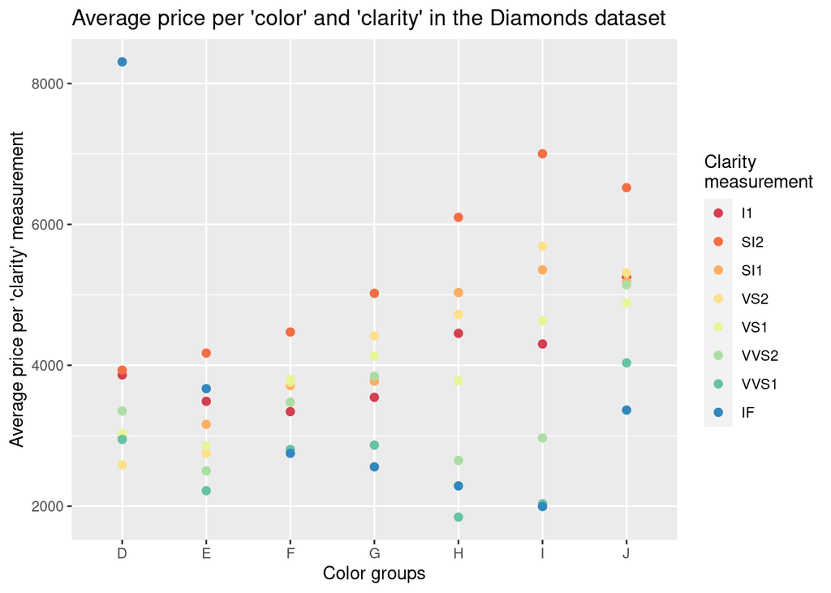

```r
ggplot(color_clarity_data,
       aes(color,
           average_price,
           colour=clarity)) +
  scale_colour_brewer(name="Clarity\nmeasurement", palette = "Spectral") +
  geom_point(size=2) +
  labs(x="Color groups",
       y="Average price per 'clarity' measurement",
       title="Average price per 'color' and 'clarity' in the Diamonds dataset")
```

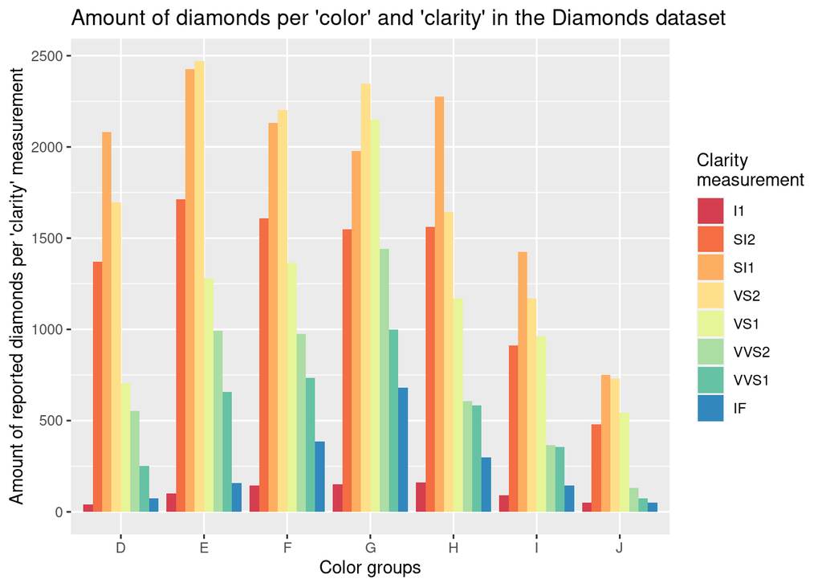

```r
ggplot(color_clarity_data,
       aes(x = color,
           y = count,
           fill = clarity)) +
  scale_fill_brewer(name="Clarity\nmeasurement", palette = "Spectral") +
  geom_bar(stat = "identity",
           position = "dodge") +
  labs(x="Color groups",
       y="Amount of reported diamonds per 'clarity' measurement",
       title="Amount of diamonds per 'color' and 'clarity' in the Diamonds dataset")
```

## -9- Counting of ‘cut’ & ‘color’ groups

```r
color_cut_data <- data %>%
  group_by(color, cut) %>%
  summarise(count = n())

color_cut_data
```

```
## # A tibble: 35 x 3
## # Groups:   color [7]
##    color cut       count
##    <ord> <ord>     <int>
##  1 D     Fair        163
##  2 D     Good        662
##  3 D     Very Good  1513
##  4 D     Premium    1603
##  5 D     Ideal      2834
##  6 E     Fair        224
##  7 E     Good        933
##  8 E     Very Good  2400
##  9 E     Premium    2337
## 10 E     Ideal      3903
## # … with 25 more rows
```

We reuse the function used to construct the barplot in question 8 to plot the amount of reported diamonds per ‘color’ groupings and ‘cut’ quality.

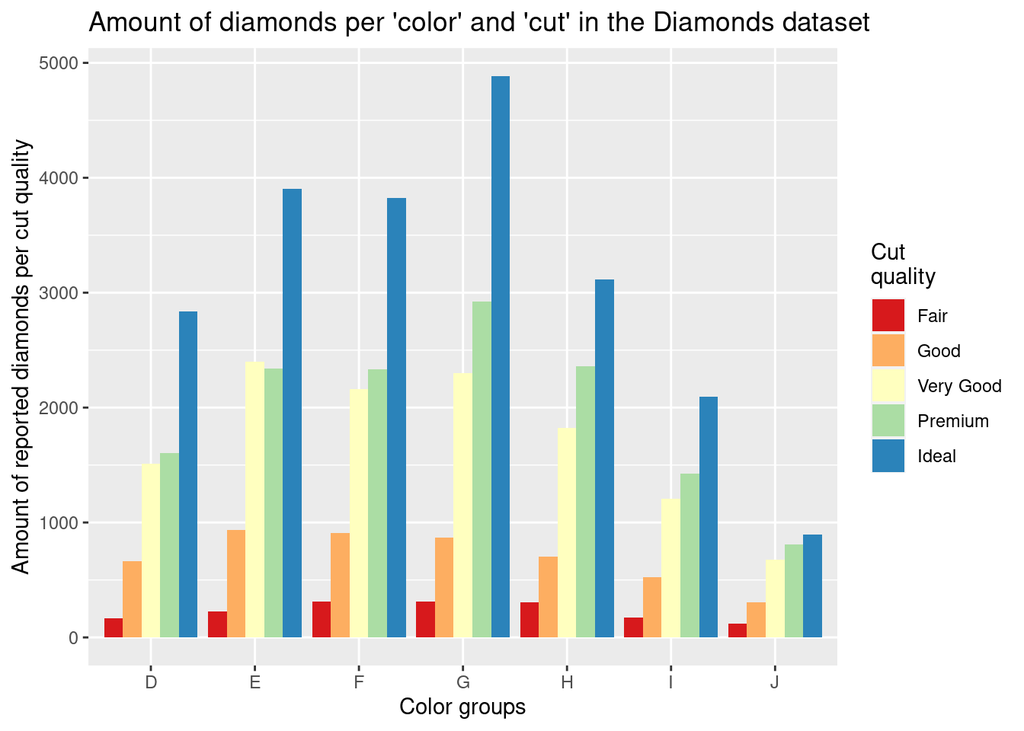

## -10- Visualizing the mean characteristics of each ‘clarity’ category

We want to find the mean value of each numeric variable characterizing a ‘clarity’ category of diamonds. By plotting the different numeric features we have at our disposal, we observe that **the quality of a diamond seems inversely proportional to its size and weight** (carat).

```r
clarity_means <- data %>% group_by(clarity) %>% select_if(is.numeric) %>% summarise_all(mean)

clarity_means
```

```
## # A tibble: 8 x 8
##   clarity carat depth table price     x     y     z
##   <ord>   <dbl> <dbl> <dbl> <dbl> <dbl> <dbl> <dbl>
## 1 I1      1.28   62.7  58.3 3924.  6.76  6.71  4.21
## 2 SI2     1.08   61.8  57.9 5063.  6.40  6.40  3.95
## 3 SI1     0.850  61.9  57.7 3996.  5.89  5.89  3.64
## 4 VS2     0.764  61.7  57.4 3925.  5.66  5.66  3.49
## 5 VS1     0.727  61.7  57.3 3839.  5.57  5.58  3.44
## 6 VVS2    0.596  61.7  57.0 3284.  5.22  5.23  3.22
## 7 VVS1    0.503  61.6  56.9 2523.  4.96  4.98  3.06
## 8 IF      0.505  61.5  56.5 2865.  4.97  4.99  3.06
```

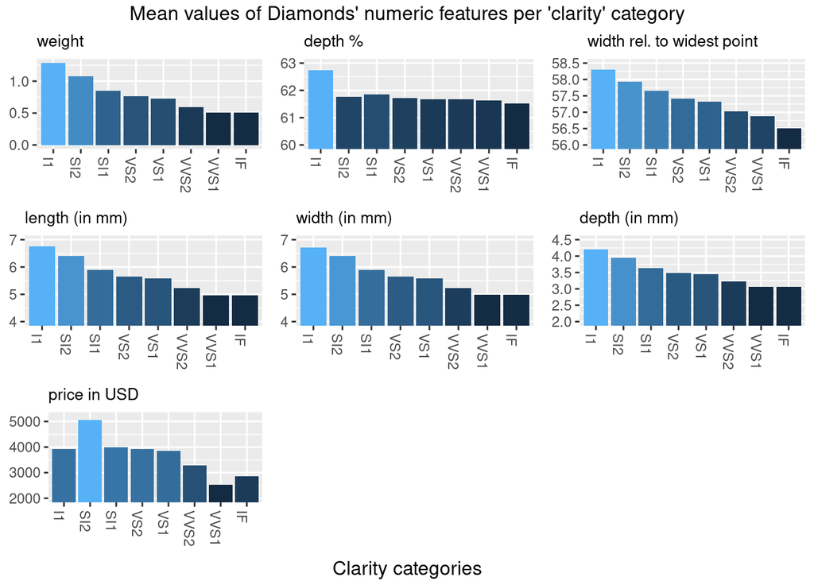

## -11- Relationship between diamond quality and price

We are interested in the relationship between the quality of a diamond (i.e. ‘cut’, ‘color’, and ‘clarity’) and its ‘price.’

Our observations are:

1. **The mean ‘price’ seems to increase as the ‘cut’ quality of a diamond decreases** (inverse correlation)
2. **The mean ‘price’ seems to increase as the ‘color’ of a diamond worsens** (inverse correlation)
3. **The mean ‘price’ seems to increase as the ‘clarity’ measurement of a diamond worsens** (inverse correlation)
4. Each quality category shows a large amount of outliers with regards to ‘price’

The negative relationship between ‘quality’ and ‘price’ might indicate that there is a discriminatory process during the selection for sale of a diamond. Indeed, based on our observations in -10-, we might supposed the following hypotheses:

> The negative relationship between ‘quality’ and ‘price’, coupled with a positive relationship between ‘carat’ and ‘price’, might indicate that the size of the low quality diamonds counter-balances the potential decrease in value its quality would have.

> Furthermore, it is possible that most small, low-quality diamonds are discarded during the production chain of diamons, meaning they will never be sold. That situation would impact and skew the pricing of low-quality diamonds upward.

Of note, using a logarithmic scale may help better visualize the relationships.

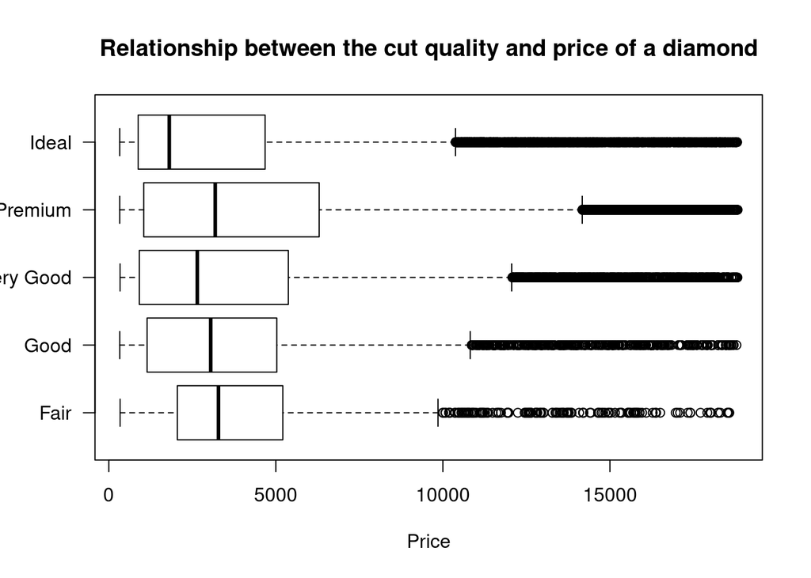

```r
boxplot(price ~ cut, data = data,
        xlab = "Price", ylab = "",
        main = "Relationship between the cut quality and price of a diamond",
        horizontal=TRUE, las = 1)
```

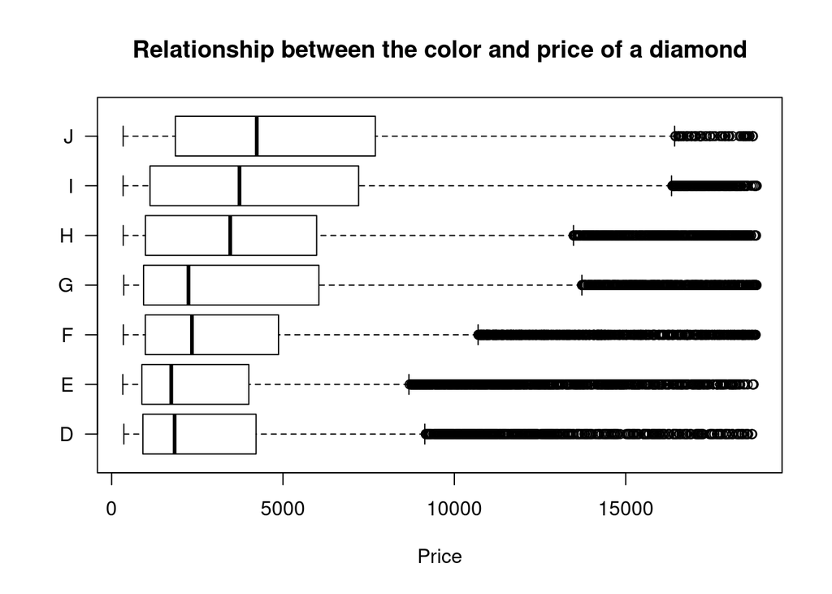

```r
boxplot(price ~ color, data = data,
        xlab = "Price", ylab = "",
        main = "Relationship between the color and price of a diamond",
        horizontal=TRUE, las=1)
```

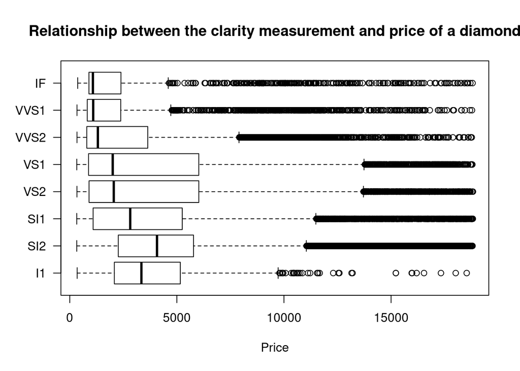

```r
boxplot(price ~ clarity, data = data,
        xlab = "Price", ylab = "",
        main = "Relationship between the clarity measurement and price of a diamond",
        horizontal=TRUE, las=1)
```

## -12 & 13- Relationship between weight (‘carat’) and ‘price’

We focus on diamonds smaller than 2.5 carats.

```r
pruned_large_carat_data <- data %>% filter(carat < 2.5)
```

We log transform the ‘carat’ and ‘price’ values of the dataset:

```r
pruned_large_carat_data$log_carat = log(pruned_large_carat_data$carat)
pruned_large_carat_data$log_price = log(pruned_large_carat_data$price)
```

We then plot the relationship between the two variables.

We observe a **strong positive relationship between size (‘carat’) and ‘price’**.

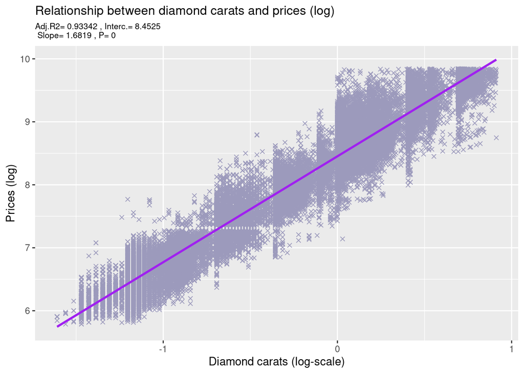

```r
ggplotRegression <- function(fit, x_title, title_size, subtitle_size, plot_title){
  ggplot(fit$model, aes_string(x = names(fit$model)[2],
                               y = names(fit$model)[1])) +
    geom_point(shape=4, color="#9c9abc") +
    stat_smooth(method = "lm", col = "purple") +
    theme(plot.title = element_text(size=title_size),
          plot.subtitle = element_text(size=subtitle_size)) +
    labs(x=x_title,
         y="Prices (log)",
         title=plot_title,
         subtitle=paste("Adj.R2=",signif(summary(fit)$adj.r.squared, 5),
                        ", Interc.=",signif(fit$coef[[1]],5 ),"\n",
                        "Slope=",signif(fit$coef[[2]], 5),
                        ", P=",signif(summary(fit)$coef[2,4], 5)))
}

# Identify and remove outliers for a better data visualization
outliers <- boxplot(pruned_large_carat_data$log_carat, plot = FALSE)$out
no_outliners <- pruned_large_carat_data[!(pruned_large_carat_data$log_carat %in% outliers), ]

ggplotRegression(lm(log_price ~ log_carat, data = no_outliners),
                 "Diamond carats (log-scale)",
                 12, 8,
                 "Relationship between diamond carats and prices (log)")
```

## -14- Relationship between ‘price’ and other numeric features

For the purpose of visualizing relationships between diamond prices and numeric features, we prune outliers using the following process:

```r
# df$var = log(df$var)
# outliers <- boxplot(df$var, plot = FALSE)$out
# df_without_outliers = df[!(df$var %in% outliers), ]
```

Given the following plots, we find that **price has a weakly positive relationship with the “width of top of diamond relative to widest point” variable and a non-existent relationship with the “total depth percentage” variable** – their adjusted R2 being close to 0 also shows that they are not good predictors of price. However, we see that there is a **positive relationship between the price and the various size variables**.

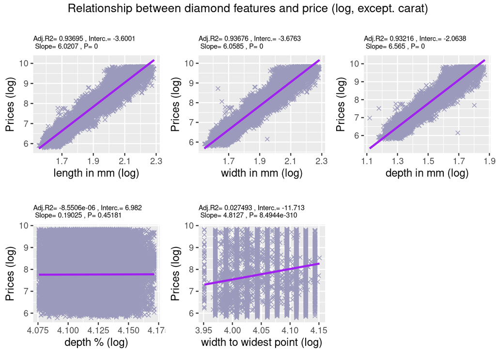

```r
p1 <- ggplotRegression(lm(log_price ~ log_x, data = no_outliners),
                       "length in mm (log)",
                       10, 7,"")
p2 <- ggplotRegression(lm(log_price ~ log_y, data = no_outliners),
                       "width in mm (log)",
                       10, 7,"")
p3 <- ggplotRegression(lm(log_price ~ log_z, data = no_outliners),
                       "depth in mm (log)",
                       10, 7,"")
p4 <- ggplotRegression(lm(log_price ~ log_depth, data = no_outliners),
                       "depth % (log)",
                       10, 7,"")
p5 <- ggplotRegression(lm(log_price ~ log_table, data = no_outliners),
                       "width to widest point (log)",
                       10, 7,"")

grid.arrange(p1, p2, p3, p4, p5, nrow = 2,
             top = "Relationship between diamond features and price (log, except. carat)")
```

One thing we might want to check is the correlation between ‘x’, ‘y’, and ‘z’ and the ‘carat’ variable. Indeed, intuitively, the three variables should be highly correlated and even dependent on the ‘carat’.

As we see below with a Pearson correlation coefficient, **‘x’, ‘y’, and ‘z’ are as much as 97.5% correlated with ‘carat’**.

```r
data %>% select(c(x,y,z,carat)) %>%
  correlate() %>%
  focus(carat)
```

```
## # A tibble: 3 x 2
##   term  carat
##   <chr> <dbl>
## 1 x     0.975
## 2 y     0.952
## 3 z     0.953
```

## -In-Between- Correlation between ‘carat’, ‘cut’, and ‘clarity’

To finalize our analysis, we can use the Kruskal-Wallis test to check the correlation between categorical and numeric values (i.e. here ‘carat’ vs. ‘cut’, and ‘carat’ vs. ‘clarity’). A low p-value would indicate a strong correlation. We can see the correlation by box-plotting each pair of variable against each other.

```r
kruskal.test(carat ~ cut, data=data)
```

```
##
##  Kruskal-Wallis rank sum test
##
## data:  carat by cut
## Kruskal-Wallis chi-squared = 1785.5, df = 4, p-value < 2.2e-16
```

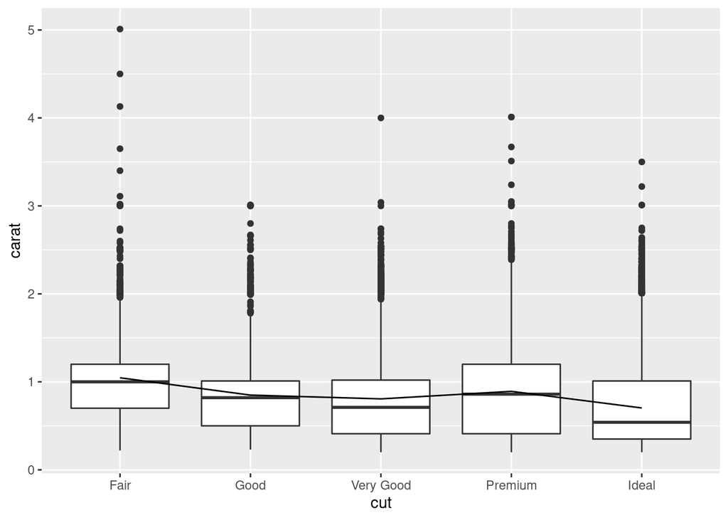

```r
cut_data <- data %>% group_by(cut) %>% summarise(mean_y = mean(carat))
ggplot(data) + geom_boxplot(aes(x = cut, y = carat)) +
   geom_path(data = cut_data, aes(x = cut, y = mean_y, group = 1))
```

```r
kruskal.test(carat ~ clarity, data=data)
```

```
##
##  Kruskal-Wallis rank sum test
##
## data:  carat by clarity
## Kruskal-Wallis chi-squared = 8057.1, df = 7, p-value < 2.2e-16
```

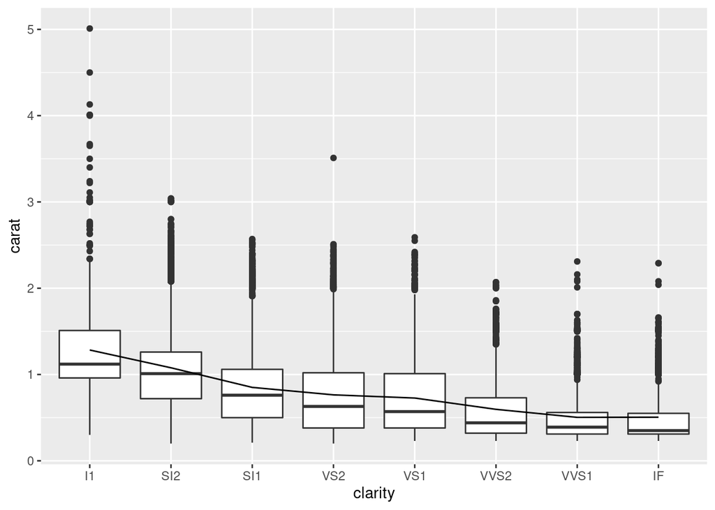

```r
clarity_data <- data %>% group_by(clarity) %>% summarise(mean_y = mean(carat))
ggplot(data) + geom_boxplot(aes(x = clarity, y = carat)) +
   geom_path(data = clarity_data, aes(x = clarity, y = mean_y, group = 1))
```

```r
kruskal.test(carat ~ color, data=data)
```

```
##
##  Kruskal-Wallis rank sum test
##
## data:  carat by color
## Kruskal-Wallis chi-squared = 3783.1, df = 6, p-value < 2.2e-16
```

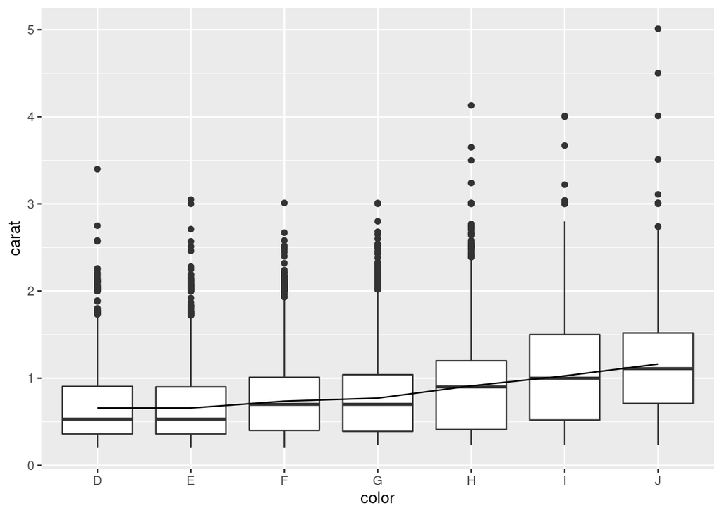

```r
color_data <- data %>% group_by(color) %>% summarise(mean_y = mean(carat))
ggplot(data) + geom_boxplot(aes(x = color, y = carat)) +
   geom_path(data = color_data, aes(x = color, y = mean_y, group = 1))
```

## -15- Regression on the original data

Now let’s go back to the original data and check the effect of each variable on the price.

As a note:

> R’s default is to fit a series of polynomial functions or contrasts to the levels of the variable. The first is linear (.L), the second is quadratic (.Q), the third is cubic (.C), and so on. R will fit one fewer polynomial functions than the number of available levels

The model shows that ‘carat’ does show a lot of impact towards the ‘price’ along with ‘clarity’ and ‘cut’, as expected.

```r
fit <- glm(price ~ carat + x + y + z + depth + table +
             factor(cut) + factor(color) + factor(clarity),
           data=data,
           family=gaussian)
summary(fit)
```

```
##
## Call:
## glm(formula = price ~ carat + x + y + z + depth + table + factor(cut) +
##     factor(color) + factor(clarity), family = gaussian, data = data)
##
## Deviance Residuals:
##      Min        1Q    Median        3Q       Max
## -21376.0    -592.4    -183.5     376.4   10694.2
##
## Coefficients:
##                    Estimate Std. Error  t value Pr(>|t|)
## (Intercept)        5753.762    396.630   14.507  < 2e-16 ***
## carat             11256.978     48.628  231.494  < 2e-16 ***
## x                 -1008.261     32.898  -30.648  < 2e-16 ***
## y                     9.609     19.333    0.497  0.61918
## z                   -50.119     33.486   -1.497  0.13448
## depth               -63.806      4.535  -14.071  < 2e-16 ***
## table               -26.474      2.912   -9.092  < 2e-16 ***
## factor(cut).L       584.457     22.478   26.001  < 2e-16 ***
## factor(cut).Q      -301.908     17.994  -16.778  < 2e-16 ***
## factor(cut).C       148.035     15.483    9.561  < 2e-16 ***
## factor(cut)^4       -20.794     12.377   -1.680  0.09294 .
## factor(color).L   -1952.160     17.342 -112.570  < 2e-16 ***
## factor(color).Q    -672.054     15.777  -42.597  < 2e-16 ***
## factor(color).C    -165.283     14.725  -11.225  < 2e-16 ***
## factor(color)^4      38.195     13.527    2.824  0.00475 **
## factor(color)^5     -95.793     12.776   -7.498 6.59e-14 ***
## factor(color)^6     -48.466     11.614   -4.173 3.01e-05 ***
## factor(clarity).L  4097.431     30.259  135.414  < 2e-16 ***
## factor(clarity).Q -1925.004     28.227  -68.197  < 2e-16 ***
## factor(clarity).C   982.205     24.152   40.668  < 2e-16 ***
## factor(clarity)^4  -364.918     19.285  -18.922  < 2e-16 ***
## factor(clarity)^5   233.563     15.752   14.828  < 2e-16 ***
## factor(clarity)^6     6.883     13.715    0.502  0.61575
## factor(clarity)^7    90.640     12.103    7.489 7.06e-14 ***
## ---
## Signif. codes:  0 '***' 0.001 '**' 0.01 '*' 0.05 '.' 0.1 ' ' 1
##
## (Dispersion parameter for gaussian family taken to be 1277113)
##
##     Null deviance: 8.5847e+11  on 53939  degrees of freedom
## Residual deviance: 6.8857e+10  on 53916  degrees of freedom
## AIC: 911504
##
## Number of Fisher Scoring iterations: 2
```

[figure not shown]

## -CONCLUSION-

We return to our driving Question: **Why are low-quality diamonds more expensive?**

We found in **Q4** that the dataset did not provide many instances of ‘fair’ or ‘good’ diamond under $600 (less than 1% of the total). This situation implies that some diamonds might be missing from the dataset. A good intuition is that low quality diamonds that do not pass a certain threshold would be discarded before hitting the market. **Q9** only reinforced the fact that the number of low cut quality diamonds (there, per ‘color’ group) is low.

Furthermore, **Q8** highlighted that the intuition that the ‘clarity’ of a diamond would positively impact its ‘price’ might not hold as low ‘clarity’ diamonds tended to yield a higher price within the same color group.

**Q14** and our **in-between** show that in fine, ‘carat’ is correlated to ‘cut’ and ‘clarity’.

In the end, we remain with ‘carat’, ‘color’, ‘cut’, and ‘clarity’ as the main predictor of price. However, since we found that ‘color’, ‘cut’, and ‘clarity’ are correlated to ‘carat’ we can focus on carat alone. And so we can go back to **Q1** and our **in-between** and confidently conclude:

> **The reason why low quality diamonds tend to be more expensive is because they are generally of a higher carat than the rest of the market.**